# An introduction to the EJSCREENbatch tool

A.R. El-Khattabi, Morgan Teachey & Adam Theising

2021-07-13

Environmental justice (EJ) analyses summarize demographics of local populations and environmental burden in order to study the impacts policy decisions may have on different communities. While impacts are often localized, it is helpful for decision makers to be able to assess impacts across many areas at once, allowing for comparison between communities and across regulatory actions. To streamline initial screening-level EJ analysis efforts, this package was developed to leverage national demographic and environmental datasets made available through the U.S. Environmental Protection Agency. Specifically, it allows users to analyze EJ summary statistics for an unlimited number of locations (coordinates or water features) and produces customized figures and maps based on user specifications.

The EJSCREENbatch R package primarily relies on data provided by [EJSCREEN](https://www.epa.gov/ejscreen), a mapping and screening tool maintained by EPA that provides demographic and environmental impact data on the Census Block Group (CBG) level for the United States. For information on how these data were prepared, refer to the [EJSCREEN Technical Information Guidance](https://www.epa.gov/ejscreen/technical-documentation-ejscreen)

## Getting started

To access the latest version of the package, simply install from the EPA’s Github Repo:

```r
# Import EJSCREENbatch package
library(devtools)
install_github(repo = "USEPA/EJSCREENbatch")
```

Then load the package, and set your working directory to that of your input data. (Note: as of V1.0, you must also create an object with the filepath housing the SEDAC raster.)

```r
library(EJSCREENbatch)

# Set directory and local pointer to SEDAC raster file.
  user<-tolower(Sys.getenv("USERNAME"))

  if(user=="aelkhatt"){
    setwd("C:/Users/aelkhatt/OneDrive - Environmental Protection Agency (EPA)/Documents/projects/environmental justice/EJSCREEN")
    path.raster.layer <- "EJScreen/US Census Grid_SF2010_TIFF"

  } else if(user=="atheisin"){
    setwd("C:/Users/atheisin/OneDrive - Environmental Protection Agency (EPA)/ejscreen")
    raster.path <- 'C:/Users/atheisin/Downloads/EJ_example/US Census Grid_SF2010_TIFF'

  } else if(user=="mteachey"){
    print("Morgan")

  }
```

## Input data requirements

First, the user supplies input location data. Since this is a batch tool, the data can (and should!) include several input locations. These locations could be points in space (i.e. lat/long coordinates of an emitting facility), boundary shapes (i.e. a set of polygons representing wetlands or lagoons), or a waterbody identifier from the NHDPlus database (more on this below).

Here create a toy data set by drawing 20 random latitude/longitude coordinates from the continental USA. These points will serve as our “locations of interest” for the vignette’s sample EJ analysis.

```r
## Draw random points from the lower 48
# Bounding box is: Extent: (-124.848974, 24.396308) * (-66.885444, 49.384358)
set.seed(202)
rnd.pts <- as.data.frame(cbind(name = paste0('facility_name_',1:20),
                 longitude = rnorm(20)*8.75 + -95.15,
                 latitude = rnorm(20)*3 + 37)) %>%
  st_as_sf(coords = c('longitude', 'latitude'), crs = 4326)
```

One important technical item to note: location inputs must be fed into package functions either (1) as a *simple feature* (sf) dataframe for point/line/polygon shapes or (2) as a *list* of catchment common identifiers (COMIDs). See the [sf package](https://r-spatial.github.io/sf/index.html) documentation for a primer on using spatial data in R and the [nhdplusTools package](https://usgs-r.github.io/nhdplusTools/) for an overview of the catchment ID data structure.

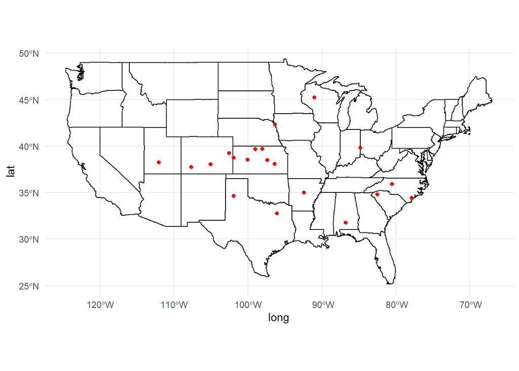

```r
# See where these imaginary facilities fall:
library(maps); library(ggplot2)
state.data <- map_data('state')
ggplot() +
  geom_polygon(data=state.data, aes(x=long, y=lat, group = group),
               color="black", fill=NA) +
  geom_sf(data = rnd.pts, color = 'red') +
  theme_minimal()
```

## Analysis with coordinate locations

```r
knitr::knit_exit()
```